# Prediction assignment

Adrian Martin

August 31, 2016

```r
if(file.exists("C:/Users/am4337/Documents/R/coursera/har.RDATA")){
    load(file = "C:/Users/am4337/Documents/R/coursera/har.RDATA", verbose = FALSE)
} else{
    raw.train <- read.csv(file = "https://d396qusza40orc.cloudfront.net/predmachlearn/pml-training.csv",
                  stringsAsFactors = FALSE)
    raw.test <- read.csv(file = "https://d396qusza40orc.cloudfront.net/predmachlearn/pml-testing.csv",
                 stringsAsFactors = FALSE)
    save(list = c("raw.train", "raw.test"),
         file = "C:/Users/am4337/Documents/R/coursera/har.RDATA")
}
df <- raw.train
```

## Data Exploration

###### My first step will be to try to understand the data better. When I use the head() function to look at the data, I see a lot of NA values. So I want to learn how prevalent NA values are. I can use table(is.na()) and use apply() to look at all columns.

```r
library(caret)
library(MASS)
library(plyr); library(dplyr)

num.na <- function(x){return(sum(is.na(x)))}
na.df <- dplyr::summarize_each(df, funs(num.na)) %>% t() %>% as.data.frame()
na.df$VarName <- row.names(na.df); na.df$NumofNAs <- na.df$V1; na.df <- na.df[,2:3]; row.names(na.df) <- NULL
cat(paste0("Number of complete cases is ", nrow(df[complete.cases(df),])))
```

```
## Number of complete cases is 406
```

```r
cat(paste0("Number of complete columns is ", nrow(dplyr::filter(na.df, NumofNAs == 0))))
```

```
## Number of complete columns is 93
```

So we have the choice of using all columns but only 406 rows, or using all 19622 rows but only 93 of the 160 columns. Of course, if only 406 out of 19622 rows are complete in the training data, probably most rows in the test data will also be incomplete. So let’s drop the columns that are usually incomplete, and go from there.

```r
vars <- na.df$VarName[which(na.df$NumofNAs == 0)]
df <- df[, vars]
```

93 variables is still a lot. Let’s look at the variables themselves and see if we can eliminate non-predictive variables. For instance, “X” is simply the row number of that observation in the dataset. That should not be used for prediction. Similarly, the timestamp variables and window variables are not based on accelerometer data.

```r
df <- df[, !grepl(pattern = "^X$|timestamp|window", x = names(df), ignore.case = TRUE)]
```

Now we’re down to 87 variables. Let’s look at what’s left.

```r
str(df[,1:15])
```

```
## 'data.frame':    19622 obs. of  15 variables:
##  $ user_name           : chr  "carlitos" "carlitos" "carlitos" "carlitos" ...
##  $ roll_belt           : num  1.41 1.41 1.42 1.48 1.48 1.45 1.42 1.42 1.43 1.45 ...
##  $ pitch_belt          : num  8.07 8.07 8.07 8.05 8.07 8.06 8.09 8.13 8.16 8.17 ...
##  $ yaw_belt            : num  -94.4 -94.4 -94.4 -94.4 -94.4 -94.4 -94.4 -94.4 -94.4 -94.4 ...
##  $ total_accel_belt    : int  3 3 3 3 3 3 3 3 3 3 ...
##  $ kurtosis_roll_belt  : chr  "" "" "" "" ...
##  $ kurtosis_picth_belt : chr  "" "" "" "" ...
##  $ kurtosis_yaw_belt   : chr  "" "" "" "" ...
##  $ skewness_roll_belt  : chr  "" "" "" "" ...
##  $ skewness_roll_belt.1: chr  "" "" "" "" ...
##  $ skewness_yaw_belt   : chr  "" "" "" "" ...
##  $ max_yaw_belt        : chr  "" "" "" "" ...
##  $ min_yaw_belt        : chr  "" "" "" "" ...
##  $ amplitude_yaw_belt  : chr  "" "" "" "" ...
##  $ gyros_belt_x        : num  0 0.02 0 0.02 0.02 0.02 0.02 0.02 0.02 0.03 ...
```

```r
head(df, 1)
```

```
##   user_name roll_belt pitch_belt yaw_belt total_accel_belt
## 1  carlitos      1.41       8.07    -94.4                3
##   kurtosis_roll_belt kurtosis_picth_belt kurtosis_yaw_belt
## 1
##   skewness_roll_belt skewness_roll_belt.1 skewness_yaw_belt max_yaw_belt
## 1
##   min_yaw_belt amplitude_yaw_belt gyros_belt_x gyros_belt_y gyros_belt_z
## 1                                            0            0        -0.02
##   accel_belt_x accel_belt_y accel_belt_z magnet_belt_x magnet_belt_y
## 1          -21            4           22            -3           599
##   magnet_belt_z roll_arm pitch_arm yaw_arm total_accel_arm gyros_arm_x
## 1          -313     -128      22.5    -161              34           0
##   gyros_arm_y gyros_arm_z accel_arm_x accel_arm_y accel_arm_z magnet_arm_x
## 1           0       -0.02        -288         109        -123         -368
##   magnet_arm_y magnet_arm_z kurtosis_roll_arm kurtosis_picth_arm
## 1          337          516
##   kurtosis_yaw_arm skewness_roll_arm skewness_pitch_arm skewness_yaw_arm
## 1
##   roll_dumbbell pitch_dumbbell yaw_dumbbell kurtosis_roll_dumbbell
## 1      13.05217        -70.494    -84.87394
##   kurtosis_picth_dumbbell kurtosis_yaw_dumbbell skewness_roll_dumbbell
## 1
##   skewness_pitch_dumbbell skewness_yaw_dumbbell max_yaw_dumbbell
## 1
##   min_yaw_dumbbell amplitude_yaw_dumbbell total_accel_dumbbell
## 1                                                           37
##   gyros_dumbbell_x gyros_dumbbell_y gyros_dumbbell_z accel_dumbbell_x
## 1                0            -0.02                0             -234
##   accel_dumbbell_y accel_dumbbell_z magnet_dumbbell_x magnet_dumbbell_y
## 1               47             -271              -559               293
##   magnet_dumbbell_z roll_forearm pitch_forearm yaw_forearm
## 1               -65         28.4         -63.9        -153
##   kurtosis_roll_forearm kurtosis_picth_forearm kurtosis_yaw_forearm
## 1
##   skewness_roll_forearm skewness_pitch_forearm skewness_yaw_forearm
## 1
##   max_yaw_forearm min_yaw_forearm amplitude_yaw_forearm
## 1
##   total_accel_forearm gyros_forearm_x gyros_forearm_y gyros_forearm_z
## 1                  36            0.03               0           -0.02
##   accel_forearm_x accel_forearm_y accel_forearm_z magnet_forearm_x
## 1             192             203            -215              -17
##   magnet_forearm_y magnet_forearm_z classe
## 1              654              476      A
```

Lots of empty character vectors! Let’s pick one at random and look at it.

```r
head(as.data.frame(table(df$kurtosis_yaw_arm)))
```

```
##       Var1  Freq
## 1          19216
## 2 -0.01548     1
## 3 -0.01749     1
## 4 -0.02101     1
## 5 -0.04059     1
## 6 -0.04626     1
```

```r
tail(as.data.frame(table(df$kurtosis_yaw_arm)))
```

```
##         Var1 Freq
## 390  5.08480    1
## 391  5.43713    1
## 392  5.46450    1
## 393 50.00000    1
## 394 56.00000    1
## 395  6.97222    1
```

It looks like the character vectors are just numeric anyways, but with lots of blanks. Let’s convert them to numeric. We’ll skip the first column because it is names, not character vectors of numbers. We also skip the last column, the outcome column.

```r
for(i in 2:ncol(df)-1){
    if(class(df[,i]) == "character"){
        df[i] <- as.numeric(unlist(df[i]))
    }
}
```

Converting characters to numbers will introduce NA values, so lets check again if we should drop rows or columns. How many complete columns in the data? 53. How many complete cases in the data? 0. Pretty easy decision - we will drop columns.

```r
df <- df[, colSums(is.na(df)) == 0]
```

## Splitting in training, validation and testing datasets

###### Now that we’ve cleaned the data, let’s split the data. Because we have so many rows of data, there is plenty of data with which to split into separate training, validation and testing datasets.

```r
set.seed(123456789)
whichset <- sample(1:3, size = nrow(df), prob = c(.6, .2, .2), replace = TRUE)
training <- df[whichset == 1, ]
validation <- df[whichset == 2, ]
testing <- df[whichset == 3, ]
```

53 variables is still a lot. Let’s look for correlated variables and try to combine them.

```r
library(corrplot)
M <- abs(cor(training[, sapply(df, is.numeric)]))
diag(M) <- 0
which(M > .98, arr.ind = TRUE)
```

```
##                  row col
## total_accel_belt   4   1
## accel_belt_z      10   1
## roll_belt          1   4
## roll_belt          1  10
## gyros_dumbbell_z  33  31
## gyros_dumbbell_x  31  33
```

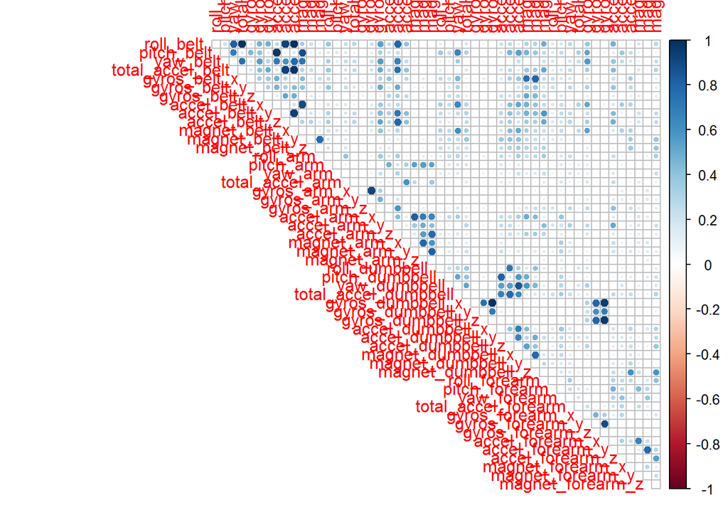

```r
corrplot(M, type = "upper")
```

It looks like there are a few highly correlated predictors. Using PCA pre-processing with a threshold of .98 will only drop us down 3 variables, and hopefully reducing some noise in the data. After PCA pre-processing, we can build a linear model.

```r
preProc <- preProcess(training[, colnames(training) != "classe"], method = "pca", thresh = .98)
trainPC <- predict(preProc, training[, colnames(training) != "classe"])
model.lda <- train(training$classe ~ ., method = "lda", data = trainPC)

preProc.validate <- preProcess(validation[, colnames(validation) != "classe"], method = "pca", thresh = .98)
validPC <- predict(preProc.validate, validation[, colnames(training) != "classe"])
confmat <- confusionMatrix(validation$classe, predict(model.lda, validPC))
confmat
```

[output not shown]

Let’s try decision-tree methods. First, a single decision tree, using the rpart2 method in caret’s train.

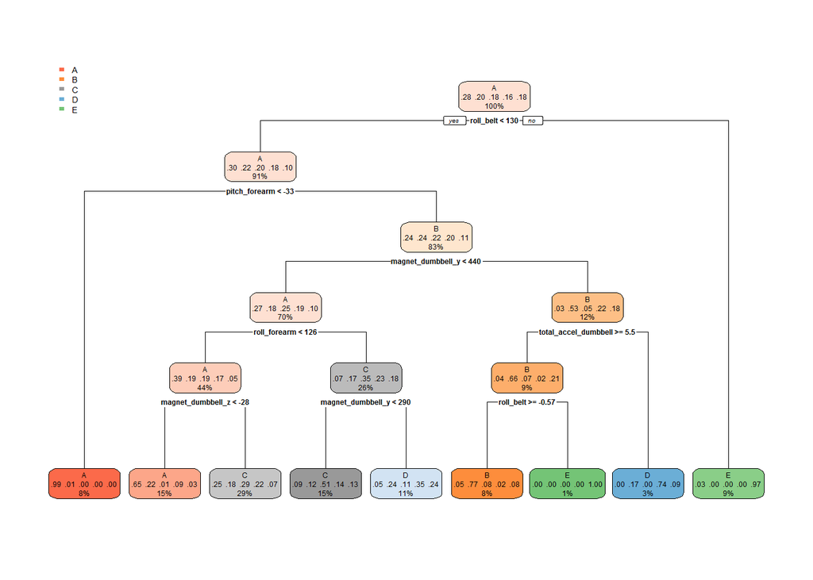

```r
library(rpart)
library(rpart.plot)
model.rpart <- train(classe ~ ., data = training, method = "rpart2", maxdepth = 10)
rpart.plot(model.rpart$finalModel)
```

```r
confusionMatrix(validation$classe, predict(model.rpart, validation))
```

```
## Confusion Matrix and Statistics
##
##           Reference
## Prediction   A   B   C   D   E
##          A 696  15 384  24  21
##          B 135 222 271 122   0
##          C   5  14 586  47   0
##          D  37  11 333 291   0
##          E  17  31 180 132 392
##
## Overall Statistics
##
##                Accuracy : 0.5514
##                  95% CI : (0.5358, 0.567)
##     No Information Rate : 0.4423
##     P-Value [Acc > NIR] : < 2.2e-16
##
##                   Kappa : 0.4412
##  Mcnemar's Test P-Value : < 2.2e-16
##
## Statistics by Class:
##
##                      Class: A Class: B Class: C Class: D Class: E
## Sensitivity            0.7820  0.75768   0.3341  0.47240  0.94915
## Specificity            0.8557  0.85625   0.9702  0.88627  0.89868
## Pos Pred Value         0.6105  0.29600   0.8988  0.43304  0.52128
## Neg Pred Value         0.9314  0.97792   0.6476  0.90134  0.99347
## Prevalence             0.2244  0.07388   0.4423  0.15532  0.10414
## Detection Rate         0.1755  0.05598   0.1478  0.07337  0.09884
## Detection Prevalence   0.2874  0.18911   0.1644  0.16944  0.18961
## Balanced Accuracy      0.8188  0.80696   0.6521  0.67934  0.92391
```

The tree did better than lda, but still the accuracy is not very good, especially for class C.

Instead, we can go with a random forest model, which my computer can handle. Random Forest also does not require preprocessing, as it can handle co-linear variables without a problem.

```r
model.rf <- train(classe ~ .,
                 data = training,
                 method = "rf",
                 #trControl = trainControl(method = "cv", number =3),
                 sampsize = 1000,
                 ntree = 100) #random forest
library(rattle)

confusionMatrix(validation$classe, predict(model.rf, validation))
```

```
## Confusion Matrix and Statistics
##
##           Reference
## Prediction    A    B    C    D    E
##          A 1126    3    8    2    1
##          B   41  685   21    1    2
##          C    0   18  623   11    0
##          D    2    3   25  640    2
##          E    3   10    9   20  710
##
## Overall Statistics
##
##                Accuracy : 0.9541
##                  95% CI : (0.9471, 0.9604)
##     No Information Rate : 0.2955
##     P-Value [Acc > NIR] : < 2.2e-16
##
##                   Kappa : 0.9419
##  Mcnemar's Test P-Value : 1.511e-12
##
## Statistics by Class:
##
##                      Class: A Class: B Class: C Class: D Class: E
## Sensitivity            0.9608   0.9527   0.9082   0.9496   0.9930
## Specificity            0.9950   0.9800   0.9912   0.9903   0.9871
## Pos Pred Value         0.9877   0.9133   0.9555   0.9524   0.9441
## Neg Pred Value         0.9837   0.9894   0.9810   0.9897   0.9984
## Prevalence             0.2955   0.1813   0.1730   0.1699   0.1803
## Detection Rate         0.2839   0.1727   0.1571   0.1614   0.1790
## Detection Prevalence   0.2874   0.1891   0.1644   0.1694   0.1896
## Balanced Accuracy      0.9779   0.9663   0.9497   0.9699   0.9900
```

Much better than the linear discriminant model! Let’s do our final cross-validation with the testing data set.

```r
confusionMatrix(testing$classe, predict(model.rf, testing))
```

```
## Confusion Matrix and Statistics
##
##           Reference
## Prediction    A    B    C    D    E
##          A 1136    5    6    1    1
##          B   42  671   16    1    0
##          C    0   22  596    8    0
##          D    7    0   20  586    1
##          E    2    9    8   16  687
##
## Overall Statistics
##
##                Accuracy : 0.957
##                  95% CI : (0.9501, 0.9632)
##     No Information Rate : 0.309
##     P-Value [Acc > NIR] : < 2.2e-16
##
##                   Kappa : 0.9453
##  Mcnemar's Test P-Value : 1.705e-12
##
## Statistics by Class:
##
##                      Class: A Class: B Class: C Class: D Class: E
## Sensitivity            0.9570   0.9491   0.9226   0.9575   0.9971
## Specificity            0.9951   0.9812   0.9906   0.9913   0.9889
## Pos Pred Value         0.9887   0.9192   0.9521   0.9544   0.9515
## Neg Pred Value         0.9811   0.9884   0.9844   0.9919   0.9994
## Prevalence             0.3090   0.1841   0.1682   0.1593   0.1794
## Detection Rate         0.2958   0.1747   0.1552   0.1526   0.1789
## Detection Prevalence   0.2991   0.1901   0.1630   0.1599   0.1880
## Balanced Accuracy      0.9761   0.9651   0.9566   0.9744   0.9930
```

Still good accuracy! Let’s get the final predictions on the test set. We’ll have to clean the test data the same way we did the training & validation data, and then predict.

```r
na.df <- dplyr::summarize_each(raw.test, funs(num.na)) %>% t() %>% as.data.frame()
na.df$VarName <- row.names(na.df); na.df$NumofNAs <- na.df$V1; na.df <- na.df[,2:3]; row.names(na.df) <- NULL

vars.test <- na.df$VarName[which(na.df$NumofNAs == 0)]
test <- raw.test[, vars.test]
test <- test[, !grepl(pattern = "^X$|timestamp|window", x = names(test), ignore.case = TRUE)]
for(i in 2:ncol(test)-1){
    if(class(test[,i]) == "character"){
        test[i] <- as.numeric(unlist(test[i]))
    }
}
test <- test[, colSums(is.na(test)) == 0]
quizanswers <- predict(model.rf$finalModel, test)
quizanswers
```

```
##  1  2  3  4  5  6  7  8  9 10 11 12 13 14 15 16 17 18 19 20
##  B  A  A  A  A  E  D  B  A  A  B  C  B  A  E  E  A  B  B  B
## Levels: A B C D E
```